# cyclistic Case Study

osama taj

2024-12-09

# Introduction

##the business task How do annual members and casual riders use Cyclistic bikes differently ?

This report analyzes bike usage patterns based on user types . The objective is to uncover insights such as: - The average trip duration by user type. - The most popular days for bike usage. - Patterns in bike usage over time.

## Data Overview

The dataset contains the following columns:

- `birthyear`: The birth year of the user.
- `gender`: The gender of the user (if available).
- `usertype`: The type of user (e.g., Subscriber, Customer).
- `to_station_name`: The name of the destination station.
- `to_station_id`: The ID of the destination station.
- `from_station_name`: The name of the starting station.
- `from_station_id`: The ID of the starting station.
- `tripduration`: The duration of each trip (in seconds).
- `bikeid`: A unique identifier for each bike.
- `end_time`: The date and time when the trip ended.
- `start_time`: The date and time when the trip began.
- `trip_id`: A unique identifier for each trip.

The dataset was originally distributed across four separate csv files. These files were imported into into R Studio and combined to a a single data frame for analysis.

The key steps in this process were: 1. **Loading the Files**: Each file was read into R using the `read.csv()` function. 2. **Combining the Data**: The individual data frames were combined using the `dplyr::bind_rows()` function. 3. **Cleaning and Preparing the Data**: Columns were standardized, and missing values were handled as necessary.

## Data Cleaning

To prepare the data for analysis, several cleaning steps were performed to ensure consistency and accuracy across the dataset:

```r
q1=read.csv("Divvy_Trips_2019_Q1.csv")
q2=read.csv("Divvy_Trips_2019_Q2.csv")
q3=read.csv("Divvy_Trips_2019_Q3.csv")
q4=read.csv("Divvy_Trips_2019_Q4.csv")
```

### Step 2: Standardizing Column Names

The column names in data frame `q2` were adjusted to match the format used in the other data frames. This ensured uniformity and facilitated the merging process.

```r
library(tidyverse)
library(dplyr)
q2 <- q2 %>%
  rename(
    trip_id = X01...Rental.Details.Rental.ID,
    start_time = X01...Rental.Details.Local.Start.Time,
    end_time = X01...Rental.Details.Local.End.Time,
    bikeid=X01...Rental.Details.Bike.ID,
      tripduration=X01...Rental.Details.Duration.In.Seconds.Uncapped,
      from_station_id=X03...Rental.Start.Station.ID,
      from_station_name=X03...Rental.Start.Station.Name,
      to_station_id=X02...Rental.End.Station.ID,
      to_station_name=X02...Rental.End.Station.Name,
      usertype=User.Type,
      gender=Member.Gender,
      birthyear=X05...Member.Details.Member.Birthday.Year
    )
```

### Step 3: Formatting Date-Time Columns

Load the required library library(lubridate)

Convert start_time and end_time in all data frames

```r
library(lubridate)
q3 <- q3 %>%
  mutate(
    start_time = format(ymd_hms(start_time), "%m/%d/%Y %H:%M:%S"),
    end_time = format(ymd_hms(end_time), "%m/%d/%Y %H:%M:%S")
    )

q4 <- q4 %>%
  mutate(
    start_time = format(ymd_hms(start_time), "%m/%d/%Y %H:%M:%S"),
    end_time = format(ymd_hms(end_time), "%m/%d/%Y %H:%M:%S")
  )

q1 <- q1 %>%
  mutate(
    end_time = mdy_hm(end_time) %>% format("%Y-%m-%d %H:%M:%S") %>% ymd_hms(),
    start_time = mdy_hm(start_time) %>% format("%Y-%m-%d %H:%M:%S") %>% ymd_hms()
  )
q2 <- q2 %>%
  mutate(
    end_time = mdy_hm(end_time) %>% format("%Y-%m-%d %H:%M:%S") %>% ymd_hms(),
    start_time = mdy_hm(start_time) %>% format("%Y-%m-%d %H:%M:%S") %>% ymd_hms()
  )
q3 <- q3 %>%
  mutate(
    end_time = mdy_hms(end_time) %>% format("%Y-%m-%d %H:%M:%S") %>% ymd_hms(),
    start_time = mdy_hms(start_time) %>% format("%Y-%m-%d %H:%M:%S") %>% ymd_hms()
  )
q4 <- q4 %>%
  mutate(
    end_time = mdy_hms(end_time) %>% format("%Y-%m-%d %H:%M:%S") %>% ymd_hms(),
    start_time = mdy_hms(start_time) %>% format("%Y-%m-%d %H:%M:%S") %>% ymd_hms()
  )
```

### Step 4: Combining All Data Frames

Combine all data frames into one

```r
library(dplyr)

all_q <- bind_rows(q1, q2, q3, q4)
```

Preview the combined data frame

```r
head(all_q)
```

```
##    trip_id          start_time            end_time bikeid tripduration
## 1 21742443 2019-01-01 00:04:00 2019-01-01 00:11:00   2167          390
## 2 21742444 2019-01-01 00:08:00 2019-01-01 00:15:00   4386          441
## 3 21742445 2019-01-01 00:13:00 2019-01-01 00:27:00   1524          829
## 4 21742446 2019-01-01 00:13:00 2019-01-01 00:43:00    252     1,783.00
## 5 21742447 2019-01-01 00:14:00 2019-01-01 00:20:00   1170          364
## 6 21742448 2019-01-01 00:15:00 2019-01-01 00:19:00   2437          216
##   from_station_id                   from_station_name to_station_id
## 1             199              Wabash Ave & Grand Ave            84
## 2              44              State St & Randolph St           624
## 3              15                Racine Ave & 18th St           644
## 4             123      California Ave & Milwaukee Ave           176
## 5             173 Mies van der Rohe Way & Chicago Ave            35
## 6              98          LaSalle St & Washington St            49
##                  to_station_name   usertype gender birthyear
## 1      Milwaukee Ave & Grand Ave Subscriber   Male      1989
## 2 Dearborn St & Van Buren St (*) Subscriber Female      1990
## 3  Western Ave & Fillmore St (*) Subscriber Female      1994
## 4              Clark St & Elm St Subscriber   Male      1993
## 5        Streeter Dr & Grand Ave Subscriber   Male      1994
## 6        Dearborn St & Monroe St Subscriber Female      1983
```

### Step 5: Extracting Day and Month Names

To facilitate time-based analysis, new columns were added to the combined data frame all_q to extract the day of the week and month from the start_time column. The wday() and month() functions from the lubridate package were used for this purpose

```r
library(lubridate)

all_q <- all_q %>%
  mutate(
    day_name = wday(start_time, label = TRUE, abbr = FALSE),  # Full day name
    month_name = month(start_time, label = TRUE, abbr = FALSE)  # Full month name
  )
```

### Step 6:Cleaning and Standardizing the Gender Column

The gender column was cleaned to ensure consistency by replacing any existing values with standardized codes:

“M” for male “F” for female “N” for not defined

```r
all_q <- all_q %>%
  mutate(
    gender = ifelse(nchar(gender) > 0, substr(gender, 1, 1), "N")
  )
```

### Step 7: Calculating Age

To calculate the age of each individual, a new column age was created. This was done by subtracting the birthyear from the current year (2024). If the birthyear is missing (NA), the age was set to 0.

```r
all_q <- all_q %>%
  mutate(
    age = ifelse(is.na(birthyear), 0, 2024-birthyear)
  )
```

### Step 8: Converting tripduration to Numeric

To ensure the tripduration column is in the correct format for analysis, it was converted from its original format to numeric using the as.numeric() function.

```r
all_q$tripduration <- as.numeric(all_q$tripduration)
```

### Step 9: Handling Missing tripduration Values

In cases where the tripduration column has missing values (NA), the duration was recalculated by subtracting the start_time from the end_time. The duration is computed in seconds using the difftime() function. If tripduration is not missing, the original value is retained.

```r
all_q <- all_q %>%
  mutate(
    tripduration = ifelse(
      is.na(tripduration),
      as.numeric(difftime(end_time, start_time, units = "secs")), # Calculate duration in seconds
      tripduration # Retain existing value if not NA
    )
  )
```

## Analysis and Results

In this analysis, we explore bike share data to uncover patterns and trends based on various factors such as user type, trip duration, time of day, and demographics. The data was cleaned and processed, and the following analyses were performed:

1. Distribution of trips by user type
2. Average trip duration for each user type
3. Most used days for each user type
4. Monthly usage patterns
5. Most used time of day for each user type
6. Gender and age distribution of users

#### Count the number of trips and percentage by user type

```r
counttypestrip <- all_q %>% count(usertype)
percentages <- all_q %>%
  count(usertype) %>%
  mutate(Percentage = round((n / sum(n)) * 100, 1))
print(percentages)
```

```
##     usertype       n Percentage
## 1   Customer  856985       22.8
## 2 Subscriber 2901431       77.2
```

the chart

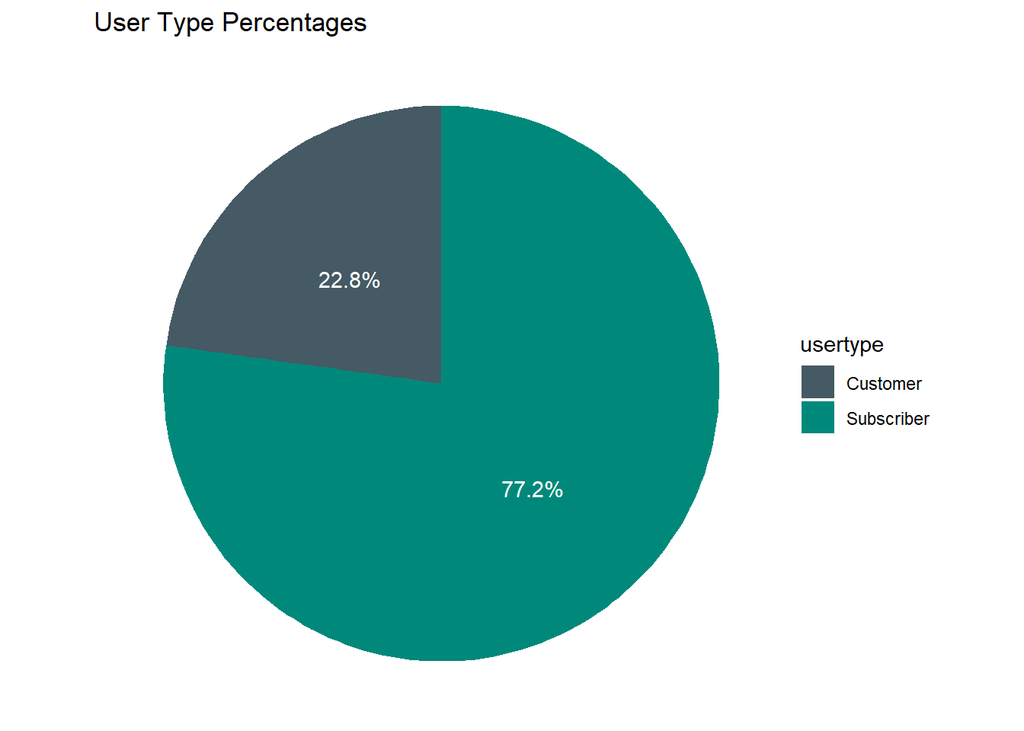

```r
mycolors <- c("#455A64","#00897B","#1E88E5")

ggplot(percentages, aes(x = "", y = Percentage, fill = usertype)) +
  geom_bar(stat = "identity", width = 1 ,) +
  coord_polar(theta = "y") +
  geom_text(aes(label = paste0(round(Percentage, 1), "%")),
            position = position_stack(vjust = 0.5), color = "white") +
  labs(title = "User Type Percentages") +
  theme_void() +
  scale_fill_manual(values = mycolors)
```

the chart show 77.2 % trips used by Subscriber and 22.8% by Customer

#### Get the average trip duration for each user type

```r
library(dplyr)
avg_tripduration <- all_q %>%
  group_by(usertype) %>%
  summarize(average_duration = mean(tripduration, na.rm = TRUE))
```

the chart

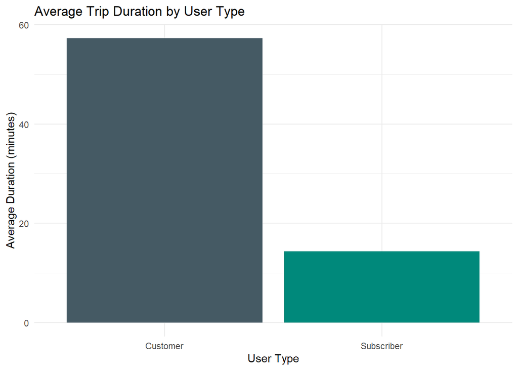

```r
ggplot(avg_tripduration, aes(x = usertype, y = average_duration / 60, fill = usertype ,)) +  # Convert seconds to minutes
  geom_bar(stat = "identity") +
  labs(title = "Average Trip Duration by User Type", x = "User Type", y = "Average Duration (minutes)") +
  theme_minimal() +
  theme(legend.position = "none")+
  scale_fill_manual(values = mycolors)
```

the chart show that the subscriber user thier avg trip duration is nearly 14 minuts and customer is thier avg duration is nealy 57 minuts

#### Find the most used day for each user type

```r
most_used_day <- all_q %>%
  group_by(usertype, day_name) %>%
  summarize(usage_count = n()) %>%
  group_by(usertype)
most_used_day <- most_used_day %>% arrange(usertype,usage_count)
```

the chart

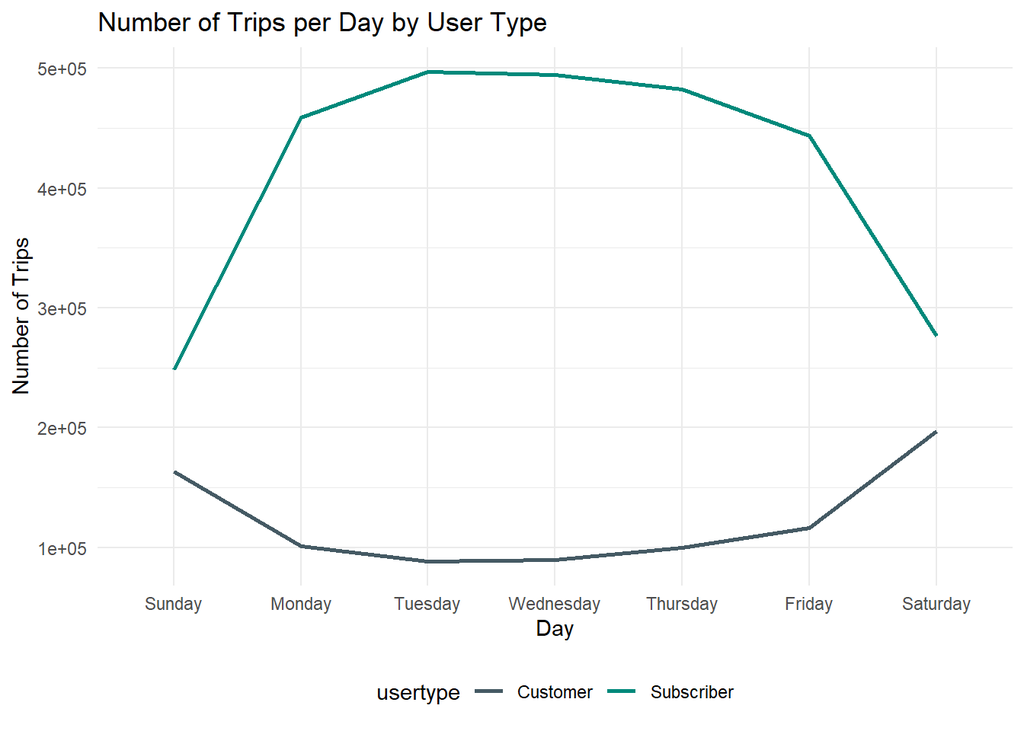

```r
ggplot(most_used_day, aes(x = day_name, y = usage_count, color = usertype, group = usertype)) +
  geom_line(size = 1) +  # Line plot with a thickness of 1
  labs(title = "Number of Trips per Day by User Type", x = "Day", y = "Number of Trips") +
  theme_minimal() +
  theme(legend.position = "bottom") +
  scale_color_manual(values = mycolors)
```

the chart shows the number of trip for Subscriber user is rises to its highest levels in the middle of the week and declines at the beginning and end of the week ,but Customer thier trip number rises to its highest levels in the the beginning and end of the week and declines in middle of the week

#### Find the most used month for each user type

```r
mounth_use <- all_q %>%
  group_by(usertype, month_name) %>%  # Group by user_type and date
  summarize(usage_count = n())
```

the chart

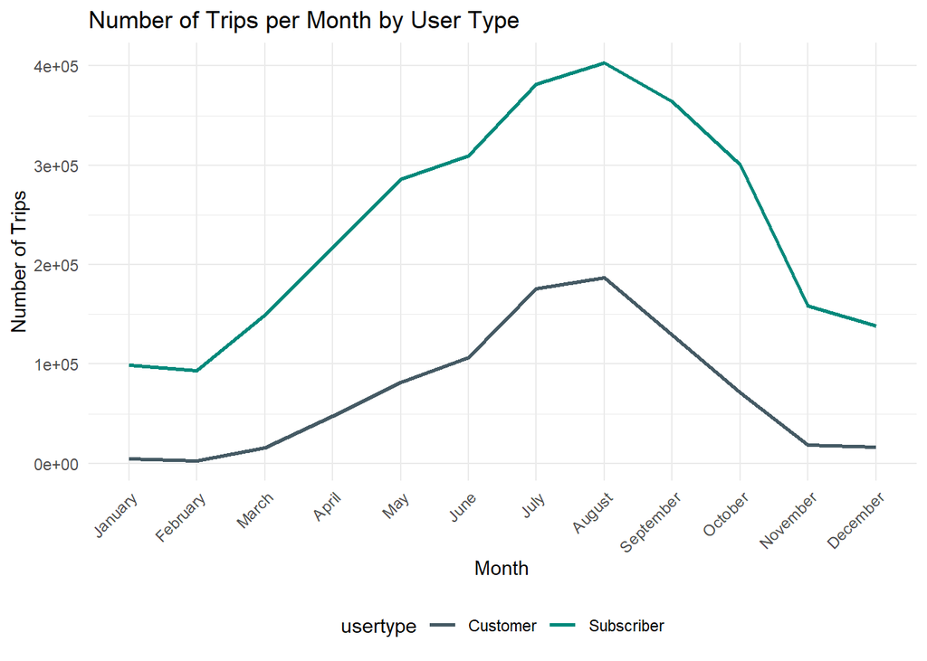

```r
ggplot(mounth_use, aes(x = month_name, y = usage_count, color = usertype, group = usertype)) +
  geom_line(size = 1) +  # Line plot with a thickness of 1
  labs(title = "Number of Trips per Month by User Type", x = "Month", y = "Number of Trips") +
  theme_minimal() +
  theme(legend.position = "bottom",
        axis.text.x = element_text(angle = 45, hjust = 1)) +
  scale_color_manual(values = mycolors)
```

the chart shows the number of trip for users Subscriber and Customer start at lowest levels in the beginning of the year and continues rise until it rises to its highest levels in the August month and declines again u until the end of the year .

#### Find the most used time for each user type

```r
sub_all_q <- data.frame()
# Extract the time of day from the date_time column

sub_all_q <- all_q %>%
  mutate(start_time = as.POSIXct(start_time, format = "%Y-%m-%d %H:%M:%S"),
         hour_of_day = format(start_time, "%H"))

sub_all_q <- sub_all_q %>%
  select(-birthyear,-gender,-to_station_name,-to_station_id,-from_station_name,-from_station_id,-tripduration,-bikeid,-end_time,-trip_id)
sub_all_q <- sub_all_q %>%
  select(-age,-month_name,-day_name,-start_time)


# Find the most used time for each user_type
most_used_time <- sub_all_q %>%
  group_by(usertype, hour_of_day) %>%  # Group by user_type and time_of_day
  summarize(usage_count = n()) %>%      # Count the number of times each time is used
  group_by(usertype)   # Get the most used time for each user_type
print(most_used_time)
```

```
## # A tibble: 48 × 3
## # Groups:   usertype [2]
##    usertype hour_of_day usage_count
##    <chr>    <chr>             <int>
##  1 Customer 00                 7892
##  2 Customer 01                 5204
##  3 Customer 02                 3230
##  4 Customer 03                 1850
##  5 Customer 04                 1129
##  6 Customer 05                 2557
##  7 Customer 06                 5992
##  8 Customer 07                12621
##  9 Customer 08                21303
## 10 Customer 09                27826
## # ℹ 38 more rows
```

the car

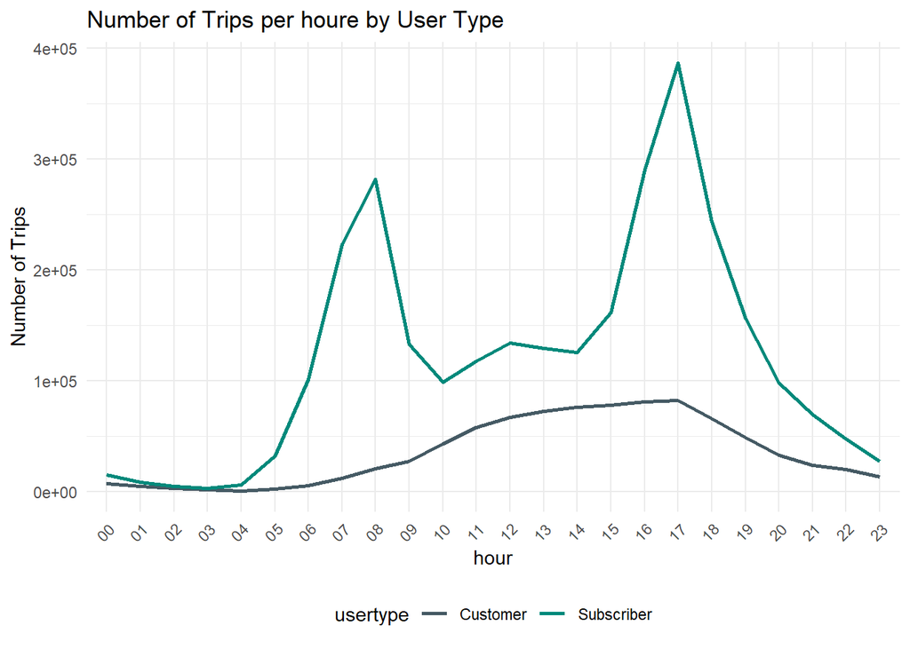

```r
ggplot(most_used_time, aes(x = hour_of_day, y = usage_count, color = usertype, group = usertype )) +
  geom_line(size = 1) +  # Line plot with a thickness of 1
  labs(title = "Number of Trips per houre by User Type", x = "hour", y = "Number of Trips") +
  theme_minimal() +
  theme(legend.position = "bottom",
        axis.text.x = element_text(angle = 45, hjust = 1)) +
  scale_color_manual(values = mycolors)
```

the chart shows the number of trip for users Subscriber its highest levels at 8.am colock and 5.pm colock , its the time for go and back from and to woek . whill Customer user at highest level at after noon

#### Find the avg age for each user type

```r
avg_age <- all_q %>%
  group_by(usertype, gender) %>%
  summarize(average_age = mean(age))
print(avg_age)
```

```
## # A tibble: 6 × 3
## # Groups:   usertype [2]
##   usertype   gender average_age
##   <chr>      <chr>        <dbl>
## 1 Customer   F           35.1
## 2 Customer   M           36.5
## 3 Customer   N            0.279
## 4 Subscriber F           39.1
## 5 Subscriber M           40.8
## 6 Subscriber N           30.7
```

#### Find the gender count for each user type

```r
gender_count <- all_q %>%
  group_by(usertype, gender) %>%
  summarize(gender_count = n())
print(gender_count)
```

```
## # A tibble: 6 × 3
## # Groups:   usertype [2]
##   usertype   gender gender_count
##   <chr>      <chr>         <int>
## 1 Customer   F            128033
## 2 Customer   M            208352
## 3 Customer   N            520600
## 4 Subscriber F            716160
## 5 Subscriber M           2162750
## 6 Subscriber N             22521
```